# Week 1: Introduction to Machine Learning for Marketing

Hands-On Lab — TMWR Chapters 1, 3, and 5

Author

IBM 6540 • Applied Machine Learning with tidymodels

Published

June 3, 2026

# 1 Overview

This document accompanies Week 1 of IBM 6540. It covers the key ideas and hands-on coding from three chapters of *Tidy Modeling with R* (TMWR):

- **Chapter 1** — Software for Modeling: what models are, why tidymodels exists
- **Chapter 3** — A Review of R Modeling Fundamentals: base R modeling, the formula interface
- **Chapter 5** — Spending Our Data: train/test splits, stratification, the data budget

By the end of this lab, you should be able to:

1. Describe the three types of models (descriptive, inferential, predictive)
2. Fit a model using base R syntax and interpret its output with tidy tools
3. Split a dataset into training and testing sets using `rsample`
4. Explain why the data budget matters and when to use stratified splits

# 2 Setup

## 2.1 Install and load packages

If you have not yet installed tidymodels, run the install line once (it is commented out below so it does not run every time you render):

```r
# Run once if needed:
# install.packages("tidymodels")
# install.packages("broom")
# install.packages("janitor")

library(tidymodels) # loads rsample, parsnip, recipes, workflows, yardstick, broom
library(tidyverse) # loads dplyr, ggplot2, tidyr, readr, etc.
```

Verify your tidymodels version:

```r
packageVersion("tidymodels")
```

```
[1] '1.5.0'
```

# 3 TMWR Chapter 1 — Software for Modeling

## 3.1 Types of models

TMWR Chapter 1 introduces a useful taxonomy. Before writing any code, it is worth asking: **what kind of model are we building, and why?**

| Type | Goal | Example |
| --- | --- | --- |
| **Descriptive** | Illustrate or summarize data | Trend line on a chart |
| **Inferential** | Test a hypothesis, estimate an effect | Does ad spend cause sales? |
| **Predictive** | Generate accurate predictions for new data | Which customers will churn? |

In this course, we focus on **predictive models** — but good predictive modeling still requires understanding your data descriptively and sometimes thinking carefully about inference.

## 3.2 The modeling process

TMWR describes modeling as an **iterative process**, not a one-shot task:

```
Exploratory data analysis
        ↓
Feature engineering
        ↓
Model fitting
        ↓
Model evaluation
        ↓
Refine (repeat as needed)
        ↓
Final model on test data
```

**Important**

**Key principle from Chapter 1:** The test set should be used **only once** — at the very end — to get an honest estimate of how well the model generalizes. Every other evaluation should use the training data only.

## 3.3 Why tidymodels?

Before tidymodels, every modeling package in R had its own syntax, its own way of making predictions, and its own output format. Compare:

```r
# Base R linear model
lm(sale_price ~ gr_liv_area, data = ames_train)

# randomForest package
randomForest(sale_price ~ gr_liv_area, data = ames_train)

# glmnet package (requires matrix input, not a formula)
glmnet(x = model.matrix(~gr_liv_area, ames_train), y = ames_train$sale_price)
```

Every package has different syntax, different prediction functions, and different output structures. tidymodels solves this by providing a **unified interface** regardless of the underlying algorithm.

# 4 TMWR Chapter 3 — R Modeling Fundamentals

## 4.1 The formula interface

The `~` (tilde) operator is central to modeling in R. It creates a **formula** that separates the outcome from the predictors:

```
outcome ~ predictor1 + predictor2 + predictor3
```

Let’s explore this with the built-in `mtcars` dataset as a warm-up before moving to marketing data.

```r
# Look at the data
glimpse(mtcars)
```

```
Rows: 32
Columns: 11
$ mpg  <dbl> 21.0, 21.0, 22.8, 21.4, 18.7, 18.1, 14.3, 24.4, 22.8, 19.2, 17.8,…
$ cyl  <dbl> 6, 6, 4, 6, 8, 6, 8, 4, 4, 6, 6, 8, 8, 8, 8, 8, 8, 4, 4, 4, 4, 8,…
$ disp <dbl> 160.0, 160.0, 108.0, 258.0, 360.0, 225.0, 360.0, 146.7, 140.8, 16…
$ hp   <dbl> 110, 110, 93, 110, 175, 105, 245, 62, 95, 123, 123, 180, 180, 180…
$ drat <dbl> 3.90, 3.90, 3.85, 3.08, 3.15, 2.76, 3.21, 3.69, 3.92, 3.92, 3.92,…
$ wt   <dbl> 2.620, 2.875, 2.320, 3.215, 3.440, 3.460, 3.570, 3.190, 3.150, 3.…
$ qsec <dbl> 16.46, 17.02, 18.61, 19.44, 17.02, 20.22, 15.84, 20.00, 22.90, 18…
$ vs   <dbl> 0, 0, 1, 1, 0, 1, 0, 1, 1, 1, 1, 0, 0, 0, 0, 0, 0, 1, 1, 1, 1, 0,…
$ am   <dbl> 1, 1, 1, 0, 0, 0, 0, 0, 0, 0, 0, 0, 0, 0, 0, 0, 0, 1, 1, 1, 0, 0,…
$ gear <dbl> 4, 4, 4, 3, 3, 3, 3, 4, 4, 4, 4, 3, 3, 3, 3, 3, 3, 4, 4, 4, 3, 3,…
$ carb <dbl> 4, 4, 1, 1, 2, 1, 4, 2, 2, 4, 4, 3, 3, 3, 4, 4, 4, 1, 2, 1, 1, 2,…
```

```r
# Fit a simple linear regression using base R
mpg_fit <- lm(mpg ~ wt + hp + cyl, data = mtcars)

# The default summary
summary(mpg_fit)
```

```
Call:
lm(formula = mpg ~ wt + hp + cyl, data = mtcars)

Residuals:
    Min      1Q  Median      3Q     Max
-3.9290 -1.5598 -0.5311  1.1850  5.8986

Coefficients:
            Estimate Std. Error t value Pr(>|t|)
(Intercept) 38.75179    1.78686  21.687  < 2e-16 ***
wt          -3.16697    0.74058  -4.276 0.000199 ***
hp          -0.01804    0.01188  -1.519 0.140015
cyl         -0.94162    0.55092  -1.709 0.098480 .
---
Signif. codes:  0 '***' 0.001 '**' 0.01 '*' 0.05 '.' 0.1 ' ' 1

Residual standard error: 2.512 on 28 degrees of freedom
Multiple R-squared:  0.8431,    Adjusted R-squared:  0.8263
F-statistic: 50.17 on 3 and 28 DF,  p-value: 2.184e-11
```

Notice that `summary()` gives us a lot of output, but it is not easy to work with programmatically — the output is printed text, not a tidy data frame.

## 4.2 Tidying model output with `broom`

The `broom` package (included in tidymodels) solves this. It provides three functions that turn model output into tidy tibbles:

| Function | What it returns |
| --- | --- |
| `tidy()` | Coefficient-level statistics |
| `glance()` | Model-level statistics (R², AIC, etc.) |
| `augment()` | Row-level statistics (fitted values, residuals) |

```r
# Coefficient-level output
tidy(mpg_fit)
```

| term | estimate | std.error | statistic | p.value |
| --- | --- | --- | --- | --- |
| (Intercept) | 38.7517874 | 1.78686403 | 21.687038 | 4.799399e-19 |
| wt | -3.1669731 | 0.74057588 | -4.276365 | 1.994765e-04 |
| hp | -0.0180381 | 0.01187625 | -1.518838 | 1.400152e-01 |
| cyl | -0.9416168 | 0.55091638 | -1.709183 | 9.848010e-02 |

```r
# Model-level output
glance(mpg_fit)
```

| r.squared | adj.r.squared | sigma | statistic | p.value | df | logLik | AIC | BIC | deviance | df.residual | nobs |
| --- | --- | --- | --- | --- | --- | --- | --- | --- | --- | --- | --- |
| 0.84315 | 0.8263446 | 2.511548 | 50.1715 | 2.184178e-11 | 3 | -72.73831 | 155.4766 | 162.8053 | 176.6205 | 28 | 32 |

```r
# Row-level output: fitted values and residuals
augment(mpg_fit) |>
  select(mpg, .fitted, .resid) |>
  head(10)
```

| mpg | .fitted | .resid |
| --- | --- | --- |
| 21.0 | 22.82043 | -1.8204257 |
| 21.0 | 22.01285 | -1.0128476 |
| 22.8 | 25.96040 | -3.1603990 |
| 21.4 | 20.93608 | 0.4639233 |
| 18.7 | 17.16780 | 1.5322025 |
| 18.1 | 20.25036 | -2.1503588 |
| 14.3 | 15.49342 | -1.1934238 |
| 24.4 | 23.76431 | 0.6356864 |
| 22.8 | 23.29574 | -0.4957351 |
| 19.2 | 19.98901 | -0.7890124 |

**Tip**

`tidy()`, `glance()`, and `augment()` work on many model types — not just `lm()`. This is one of the core benefits of the tidymodels ecosystem.

## 4.3 The formula interface — more options

The formula interface has powerful shorthand:

```r
# Include all predictors
lm(mpg ~ ., data = mtcars)

# Exclude one predictor
lm(mpg ~ . - carb, data = mtcars)

# Interaction term
lm(mpg ~ wt * hp, data = mtcars) # includes wt, hp, and wt:hp

# Explicit interaction only
lm(mpg ~ wt + hp + wt:hp, data = mtcars)

# Polynomial term
lm(mpg ~ wt + I(wt^2), data = mtcars)

# Log transformation of predictor
lm(mpg ~ log(wt) + hp, data = mtcars)
```

## 4.4 ✏️ Practice 3.1 — Explore base R modeling

Use the `mtcars` dataset to answer these questions:

```r
# 1. Fit a model predicting mpg from wt alone
fit_simple <- lm(mpg ~ wt, data = mtcars)

# Use tidy() to see the coefficients
tidy(fit_simple)
```

| term | estimate | std.error | statistic | p.value |
| --- | --- | --- | --- | --- |
| (Intercept) | 37.285126 | 1.877627 | 19.857575 | 8.241799e-19 |
| wt | -5.344472 | 0.559101 | -9.559044 | 1.293959e-10 |

```r
# 2. Use glance() to check model fit
glance(fit_simple)
```

| r.squared | adj.r.squared | sigma | statistic | p.value | df | logLik | AIC | BIC | deviance | df.residual | nobs |
| --- | --- | --- | --- | --- | --- | --- | --- | --- | --- | --- | --- |
| 0.7528328 | 0.7445939 | 3.045882 | 91.37533 | 1.293959e-10 | 1 | -80.01471 | 166.0294 | 170.4266 | 278.3219 | 30 | 32 |

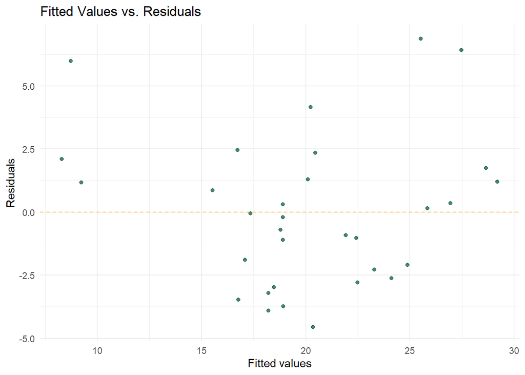

```r
# 3. Plot fitted values vs. residuals
augment(fit_simple) |>
  ggplot(aes(x = .fitted, y = .resid)) +
  geom_point(color = "#005030", alpha = 0.7) +
  geom_hline(yintercept = 0, linetype = "dashed", color = "#FFB81C") +
  labs(
    title = "Fitted Values vs. Residuals",
    x = "Fitted values",
    y = "Residuals"
  ) +
  theme_minimal()
```

**Note**

**Your turn:** Try adding `hp` and `cyl` to the model. Does R² improve? Does the residual plot look better or worse? What does that tell you?

## 4.5 A marketing dataset — customer churn

Let’s switch from `mtcars` to a more relevant marketing dataset. We will simulate a customer dataset that mirrors the kinds of data you would encounter in practice:

```r
set.seed(42)
n <- 1000

customer_data <- tibble(
  customer_id = 1:n,
  tenure = sample(1:60, n, replace = TRUE),
  monthly_spend = round(rnorm(n, mean = 85, sd = 25), 2),
  num_products = sample(
    1:5,
    n,
    replace = TRUE,
    prob = c(0.3, 0.3, 0.2, 0.1, 0.1)
  ),
  num_complaints = rpois(n, lambda = 0.5),
  last_login_days = sample(1:90, n, replace = TRUE),
  region = sample(c("West", "East", "South", "Midwest"), n, replace = TRUE),
  churn = factor(
    ifelse(
      0.05 *
        num_complaints +
        0.02 * last_login_days -
        0.015 * tenure -
        0.005 * monthly_spend +
        rnorm(n, 0, 0.5) >
        0.3,
      "yes",
      "no"
    )
  )
)

glimpse(customer_data)
```

```
Rows: 1,000
Columns: 8
$ customer_id     <int> 1, 2, 3, 4, 5, 6, 7, 8, 9, 10, 11, 12, 13, 14, 15, 16,…
$ tenure          <int> 49, 37, 1, 25, 10, 36, 18, 58, 49, 47, 24, 7, 36, 25, …
$ monthly_spend   <dbl> 70.96, 116.74, 44.22, 97.79, 67.68, 92.65, 41.63, 125.…
$ num_products    <int> 1, 2, 4, 1, 2, 2, 1, 4, 1, 3, 1, 5, 3, 3, 1, 2, 3, 3, …
$ num_complaints  <int> 1, 0, 2, 0, 0, 0, 0, 0, 0, 1, 1, 1, 1, 0, 0, 1, 2, 1, …
$ last_login_days <int> 64, 78, 6, 52, 80, 26, 53, 62, 43, 61, 3, 73, 12, 59, …
$ region          <chr> "West", "South", "West", "West", "South", "South", "Ea…
$ churn           <fct> yes, no, no, no, yes, yes, yes, no, no, yes, no, no, n…
```

```r
# Check overall churn rate
customer_data |>
  count(churn) |>
  mutate(pct = n / sum(n) * 100)
```

| churn | n | pct |
| --- | --- | --- |
| no | 631 | 63.1 |
| yes | 369 | 36.9 |

## 4.6 ✏️ Practice 3.2 — Fit a model on marketing data

```r
# 1. Fit a linear model predicting monthly_spend from tenure and num_products
spend_fit <- lm(
  monthly_spend ~ tenure + num_products + region,
  data = customer_data
)

tidy(spend_fit)
```

| term | estimate | std.error | statistic | p.value |
| --- | --- | --- | --- | --- |
| (Intercept) | 83.42355276 | 2.71242275 | 30.7561027 | 1.694850e-146 |
| tenure | 0.03790589 | 0.04895971 | 0.7742262 | 4.389812e-01 |
| num_products | 0.26560040 | 0.63207462 | 0.4202042 | 6.744271e-01 |
| regionMidwest | -0.99741025 | 2.31940978 | -0.4300276 | 6.672688e-01 |
| regionSouth | 2.71328145 | 2.26022533 | 1.2004473 | 2.302517e-01 |
| regionWest | 1.19233760 | 2.29395756 | 0.5197732 | 6.033374e-01 |

```r
# 2. Check model quality
glance(spend_fit)
```

| r.squared | adj.r.squared | sigma | statistic | p.value | df | logLik | AIC | BIC | deviance | df.residual | nobs |
| --- | --- | --- | --- | --- | --- | --- | --- | --- | --- | --- | --- |
| 0.003575459 | -0.001436737 | 25.86202 | 0.7133518 | 0.6134641 | 5 | -4668.705 | 9351.41 | 9385.764 | 664831 | 994 | 1000 |

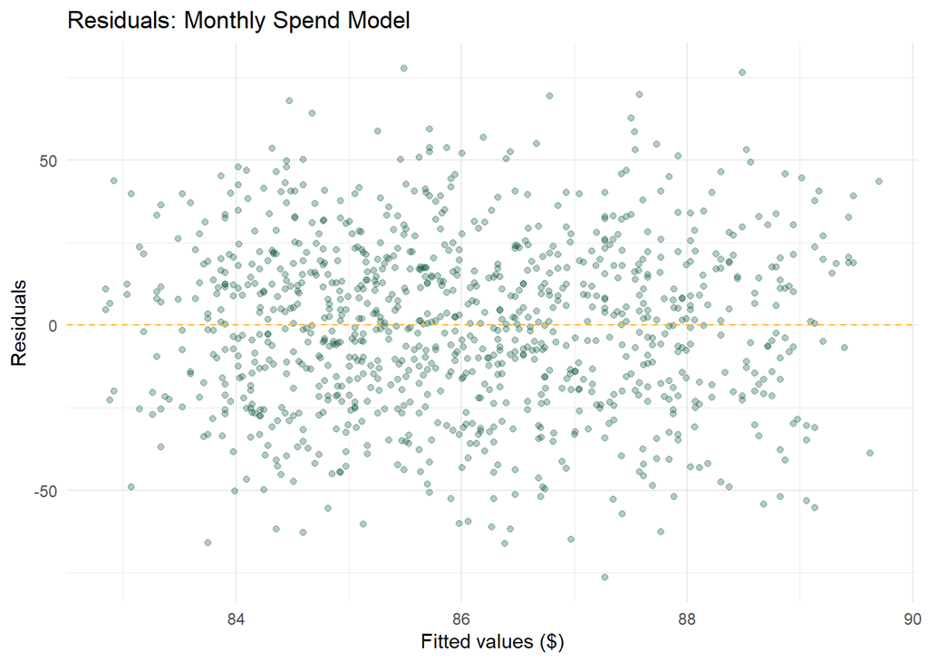

```r
# 3. Visualize residuals
augment(spend_fit) |>
  ggplot(aes(x = .fitted, y = .resid)) +
  geom_point(alpha = 0.3, color = "#005030") +
  geom_hline(yintercept = 0, linetype = "dashed", color = "#FFB81C") +
  labs(
    title = "Residuals: Monthly Spend Model",
    x = "Fitted values ($)",
    y = "Residuals"
  ) +
  theme_minimal()
```

**Note**

**Your turn:** Add `num_complaints` and `last_login_days` as predictors. What happens to R²? Does every predictor appear significant? What might this tell you about the data generating process we used to simulate the data?

# 5 TMWR Chapter 5 — Spending Our Data

## 5.1 The data budget concept

Chapter 5 introduces one of the most important ideas in applied ML:

> *We have a finite amount of data. Every time we use data to make a modeling decision, we “spend” some of its ability to give us unbiased estimates.*

The solution is to **split the data** before doing any modeling:

- **Training set** — used for everything: exploration, feature engineering, model fitting, hyperparameter tuning
- **Test set** — used **once**, at the very end, to estimate real-world performance

Data budget for our 1,000-row customer dataset

| Set | Purpose | Size |
| --- | --- | --- |
| Training (~80%) | Fit model, tune parameters, make preprocessing decisions | 800 rows |
| Testing (~20%) | Final honest estimate of model performance — used once | 200 rows |

## 5.2 Basic train/test split with `rsample`

The `rsample` package (part of tidymodels) makes splitting straightforward:

```r
library(rsample)

set.seed(123) # Always set a seed for reproducibility

# 80% training, 20% testing
customer_split <- initial_split(customer_data, prop = 0.80)

customer_split
```

```
<Training/Testing/Total>
<800/200/1000>
```

```r
# Extract the training and testing sets
customer_train <- training(customer_split)
customer_test <- testing(customer_split)

# Verify sizes
cat("Training rows:", nrow(customer_train), "\n")
```

```
Training rows: 800
```

```r
cat("Testing rows: ", nrow(customer_test), "\n")
```

```
Testing rows:  200
```

```r
cat("Total:        ", nrow(customer_train) + nrow(customer_test), "\n")
```

```
Total:         1000
```

## 5.3 Stratified splitting

First, let’s see what happens without stratification:

```r
set.seed(123)

# Without stratification
split_no_strata <- initial_split(customer_data, prop = 0.80)
train_no_strata <- training(split_no_strata)
test_no_strata <- testing(split_no_strata)

cat("Churn rate in full data:\n")
```

```
Churn rate in full data:
```

```r
customer_data |> count(churn) |> mutate(pct = round(n / sum(n) * 100, 1))
```

| churn | n | pct |
| --- | --- | --- |
| no | 631 | 63.1 |
| yes | 369 | 36.9 |

```r
cat("Churn rate in training (no strata):\n")
```

```
Churn rate in training (no strata):
```

```r
train_no_strata |> count(churn) |> mutate(pct = round(n / sum(n) * 100, 1))
```

| churn | n | pct |
| --- | --- | --- |
| no | 506 | 63.2 |
| yes | 294 | 36.8 |

```r
cat("Churn rate in testing (no strata):\n")
```

```
Churn rate in testing (no strata):
```

```r
test_no_strata |> count(churn) |> mutate(pct = round(n / sum(n) * 100, 1))
```

| churn | n | pct |
| --- | --- | --- |
| no | 125 | 62.5 |
| yes | 75 | 37.5 |

Now with stratification:

```r
set.seed(123)

# With stratification on the outcome variable
customer_split_strat <- initial_split(
  customer_data,
  prop = 0.80,
  strata = churn
) # key argument

customer_train <- training(customer_split_strat)
customer_test <- testing(customer_split_strat)

cat("Churn rate in training (stratified):\n")
```

```
Churn rate in training (stratified):
```

```r
customer_train |> count(churn) |> mutate(pct = round(n / sum(n) * 100, 1))
```

| churn | n | pct |
| --- | --- | --- |
| no | 504 | 63.1 |
| yes | 295 | 36.9 |

```r
cat("Churn rate in testing (stratified):\n")
```

```
Churn rate in testing (stratified):
```

```r
customer_test |> count(churn) |> mutate(pct = round(n / sum(n) * 100, 1))
```

| churn | n | pct |
| --- | --- | --- |
| no | 127 | 63.2 |
| yes | 74 | 36.8 |

**Tip**

**Rule of thumb:** Always use `strata =` when your outcome is a category with imbalanced classes (e.g. churn, conversion, fraud). For regression outcomes, stratification is less critical but can still help ensure consistent distributions.

## 5.4 Visualizing the split

It is good practice to verify that your training and testing sets have similar distributions for key variables:

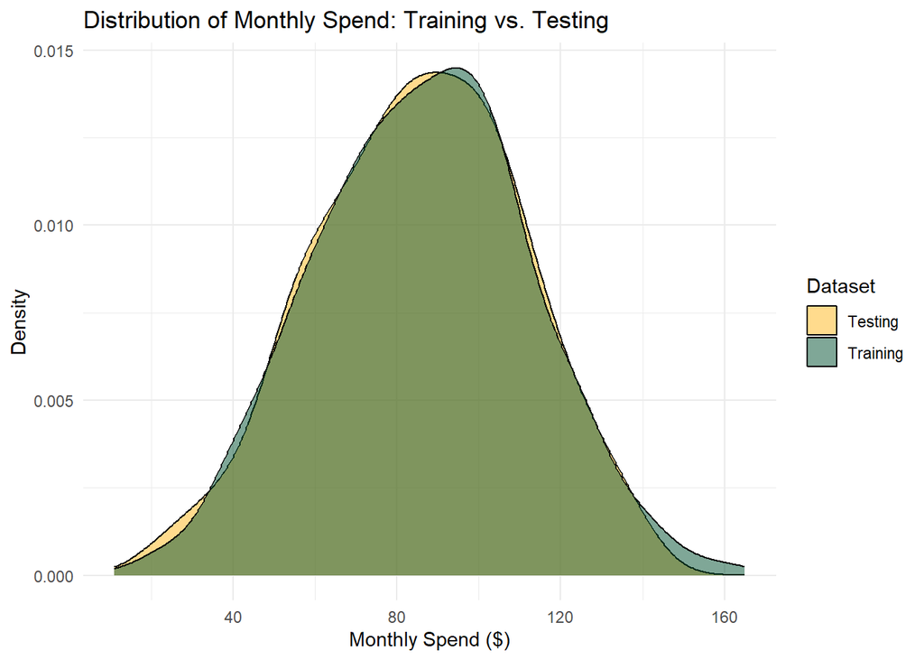

```r
# Compare distributions of monthly_spend across splits
bind_rows(
  customer_train |> mutate(set = "Training"),
  customer_test |> mutate(set = "Testing")
) |>
  ggplot(aes(x = monthly_spend, fill = set)) +
  geom_density(alpha = 0.5) +
  scale_fill_manual(values = c("Training" = "#005030", "Testing" = "#FFB81C")) +
  labs(
    title = "Distribution of Monthly Spend: Training vs. Testing",
    x = "Monthly Spend ($)",
    y = "Density",
    fill = "Dataset"
  ) +
  theme_minimal()
```

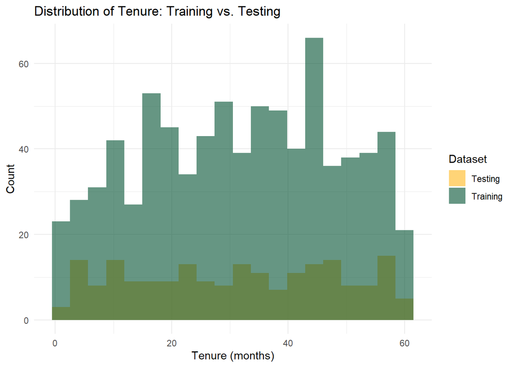

```r
# Compare tenure distributions
bind_rows(
  customer_train |> mutate(set = "Training"),
  customer_test |> mutate(set = "Testing")
) |>
  ggplot(aes(x = tenure, fill = set)) +
  geom_histogram(alpha = 0.6, bins = 20, position = "identity") +
  scale_fill_manual(values = c("Training" = "#005030", "Testing" = "#FFB81C")) +
  labs(
    title = "Distribution of Tenure: Training vs. Testing",
    x = "Tenure (months)",
    y = "Count",
    fill = "Dataset"
  ) +
  theme_minimal()
```

## 5.5 The validation set

Sometimes you want a **third** split — a validation set — for tuning hyperparameters without touching the test set:

```r
set.seed(123)

# Three-way split: 60% train, 20% validation, 20% test
customer_val_split <- initial_validation_split(
  customer_data,
  prop = c(0.6, 0.2),
  strata = churn
)

customer_val_split
```

```
<Training/Validation/Testing/Total>
<599/200/201/1000>
```

```r
train_val <- training(customer_val_split)
val_set <- validation(customer_val_split)
test_val <- testing(customer_val_split)

cat("Training:   ", nrow(train_val), "rows\n")
```

```
Training:    599 rows
```

```r
cat("Validation: ", nrow(val_set), "rows\n")
```

```
Validation:  200 rows
```

```r
cat("Testing:    ", nrow(test_val), "rows\n")
```

```
Testing:     201 rows
```

**Note**

We will use **cross-validation** (TMWR Chapter 10) as a more efficient alternative to a separate validation set in later weeks.

## 5.6 ✏️ Practice 5.1 — Splitting your own data

Work through the following steps:

```r
# Step 1: Set a seed for reproducibility
set.seed(2024)

# Step 2: Create a stratified 80/20 split on churn
# YOUR CODE HERE
practice_split <- initial_split(customer_data, prop = 0.80, strata = churn)

# Step 3: Extract training and testing sets
practice_train <- training(practice_split)
practice_test <- testing(practice_split)

# Step 4: Verify the split sizes
cat("Training rows:", nrow(practice_train), "\n")
```

```
Training rows: 799
```

```r
cat("Testing rows: ", nrow(practice_test), "\n")
```

```
Testing rows:  201
```

```r
# Step 5: Verify churn rates are similar in both sets
practice_train |>
  count(churn) |>
  mutate(pct = round(n / sum(n) * 100, 1), set = "Training") |>
  bind_rows(
    practice_test |>
      count(churn) |>
      mutate(pct = round(n / sum(n) * 100, 1), set = "Testing")
  ) |>
  select(set, churn, n, pct)
```

| set | churn | n | pct |
| --- | --- | --- | --- |
| Training | no | 504 | 63.1 |
| Training | yes | 295 | 36.9 |
| Testing | no | 127 | 63.2 |
| Testing | yes | 74 | 36.8 |

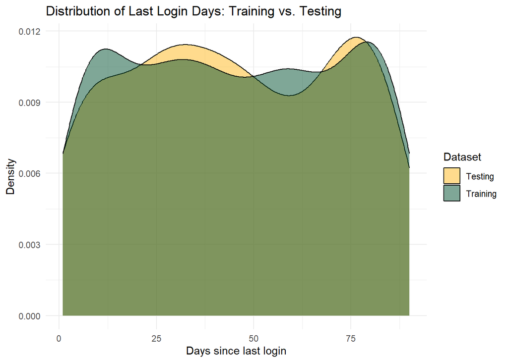

```r
# Step 6: Compare distributions of a key predictor across splits
# Try changing 'last_login_days' to other variables
bind_rows(
  practice_train |> mutate(set = "Training"),
  practice_test |> mutate(set = "Testing")
) |>
  ggplot(aes(x = last_login_days, fill = set)) +
  geom_density(alpha = 0.5) +
  scale_fill_manual(values = c("Training" = "#005030", "Testing" = "#FFB81C")) +
  labs(
    title = "Distribution of Last Login Days: Training vs. Testing",
    x = "Days since last login",
    y = "Density",
    fill = "Dataset"
  ) +
  theme_minimal()
```